# Introduction

Good morning and welcome to my project!

This project is about visualization which is a step following the data wrangling process. Before getting to the visualization the data is to be cleaned. In this project, I will make sure that the data are cleaned, tidiness and data quality will be verified, mostly for the key variables.

For this project, I suggest three main steps

- step 1: review the datasets, to verify the quality of the data and the tidiness of the dataset and understand the data’s structure, oddities.
- step 2: Exploratory data analysis on key variables, the exploration will focus on 15 variables. To select those 15 variables, we will create a sub datasets, the exploration will be conducted on this sub-dataset. I will use data visualization libraries to explore the dataset’s 15 variables patterns and relationships. The analysis will be structured, going from simple univariate relationships up through multivariate relationships.
- step 3: I will take my main findings from the exploration step2, above, and convey them to others through an explanatory analysis. To this end, I will create a slide deck that leverages polished, explanatory visualizations to communicate my results. Two major paths in my exploration will be selected, while choosing relevant visualizations along that path, and then polishing them to construct a story for the readers to understand my findings.

# Presentation of my datasets

In this project, I will work with the Loan Data from Prosper.

This data set contains 113,937 loans with 81 variables on each loan, including loan amount, borrower rate (or interest rate), current loan status, borrower income, and many others.

## What are the data about?

```
ListingKey :    Unique key for each listing, same value as the 'key' used in the listing object in the API.
ListingNumber:  The number that uniquely identifies the listing to the public as displayed on the website.
ListingCreationDate:    The date the listing was created.
CreditGrade:    The Credit rating that was assigned at the time the listing went live. Applicable for listings pre-2009 period and will only be populated for those listings.
Term:   The length of the loan expressed in months.
LoanStatus: The current status of the loan: Cancelled,  Chargedoff, Completed, Current, Defaulted, FinalPaymentInProgress, PastDue. The PastDue status will be accompanied by a delinquency bucket.
ClosedDate: Closed date is applicable for Cancelled, Completed, Chargedoff and Defaulted loan statuses.
BorrowerAPR:    The Borrower's Annual Percentage Rate (APR) for the loan.
BorrowerRate:   The Borrower's interest rate for this loan.
LenderYield:    The Lender yield on the loan. Lender yield is equal to the interest rate on the loan less the servicing fee.
EstimatedEffectiveYield:    Effective yield is equal to the borrower interest rate (i) minus the servicing fee rate, (ii) minus estimated uncollected interest on charge-offs, (iii) plus estimated collected late fees.  Applicable for loans originated after July 2009.
EstimatedLoss:  Estimated loss is the estimated principal loss on charge-offs. Applicable for loans originated after July 2009.
EstimatedReturn:    The estimated return assigned to the listing at the time it was created. Estimated return is the difference between the Estimated Effective Yield and the Estimated Loss Rate. Applicable for loans originated after July 2009.
ProsperRating (numeric):    The  Prosper Rating assigned at the time the listing was created: 0 - N/A, 1 - HR, 2 - E, 3 - D, 4 - C, 5 - B, 6 - A, 7 - AA.  Applicable for loans originated after July 2009.
ProsperRating (Alpha):  The Prosper Rating assigned at the time the listing was created between AA - HR.  Applicable for loans originated after July 2009.
ProsperScore:   A custom risk score built using historical Prosper data. The score ranges from 1-10, with 10 being the best, or lowest risk score.  Applicable for loans originated after July 2009.
ListingCategory:    The category of the listing that the borrower selected when posting their listing: 0 - Not Available, 1 - Debt Consolidation, 2 - Home Improvement, 3 - Business, 4 - Personal Loan, 5 - Student Use, 6 - Auto, 7- Other, 8 - Baby&Adoption, 9 - Boat, 10 - Cosmetic Procedure, 11 - Engagement Ring, 12 - Green Loans, 13 - Household Expenses, 14 - Large Purchases, 15 - Medical/Dental, 16 - Motorcycle, 17 - RV, 18 - Taxes, 19 - Vacation, 20 - Wedding Loans
BorrowerState:  The two letter abbreviation of the state of the address of the borrower at the time the Listing was created.
Occupation: The Occupation selected by the Borrower at the time they created the listing.
EmploymentStatus:   The employment status of the borrower at the time they posted the listing.
EmploymentStatusDuration:   The length in months of the employment status at the time the listing was created.
IsBorrowerHomeowner:    A Borrower will be classified as a homowner if they have a mortgage on their credit profile or provide documentation confirming they are a homeowner.
CurrentlyInGroup:   Specifies whether or not the Borrower was in a group at the time the listing was created.
GroupKey:   The Key of the group in which the Borrower is a member of. Value will be null if the borrower does not have a group affiliation.
DateCreditPulled:   The date the credit profile was pulled.
CreditScoreRangeLower:  The lower value representing the range of the borrower's credit score as provided by a consumer credit rating agency.
CreditScoreRangeUpper:  The upper value representing the range of the borrower's credit score as provided by a consumer credit rating agency.
FirstRecordedCreditLine:    The date the first credit line was opened.
CurrentCreditLines: Number of current credit lines at the time the credit profile was pulled.
OpenCreditLines:    Number of open credit lines at the time the credit profile was pulled.
TotalCreditLinespast7years: Number of credit lines in the past seven years at the time the credit profile was pulled.
OpenRevolvingAccounts:  Number of open revolving accounts at the time the credit profile was pulled.
OpenRevolvingMonthlyPayment:    Monthly payment on revolving accounts at the time the credit profile was pulled.
InquiriesLast6Months:   Number of inquiries in the past six months at the time the credit profile was pulled.
TotalInquiries: Total number of inquiries at the time the credit profile was pulled.
CurrentDelinquencies:   Number of accounts delinquent at the time the credit profile was pulled.
AmountDelinquent:   Dollars delinquent at the time the credit profile was pulled.
DelinquenciesLast7Years:    Number of delinquencies in the past 7 years at the time the credit profile was pulled.
PublicRecordsLast10Years:   Number of public records in the past 10 years at the time the credit profile was pulled.
PublicRecordsLast12Months:  Number of public records in the past 12 months at the time the credit profile was pulled.
RevolvingCreditBalance: Dollars of revolving credit at the time the credit profile was pulled.
BankcardUtilization:    The percentage of available revolving credit that is utilized at the time the credit profile was pulled.
AvailableBankcardCredit:    The total available credit via bank card at the time the credit profile was pulled.
TotalTrades:    Number of trade lines ever opened at the time the credit profile was pulled.
TradesNeverDelinquent:  Number of trades that have never been delinquent at the time the credit profile was pulled.
TradesOpenedLast6Months:    Number of trades opened in the last 6 months at the time the credit profile was pulled.
DebtToIncomeRatio:  The debt to income ratio of the borrower at the time the credit profile was pulled. This value is Null if the debt to income ratio is not available. This value is capped at 10.01 (any debt to income ratio larger than 1000% will be returned as 1001%).
IncomeRange:    The income range of the borrower at the time the listing was created.
IncomeVerifiable:   The borrower indicated they have the required documentation to support their income.
StatedMonthlyIncome:    The monthly income the borrower stated at the time the listing was created.
LoanKey:    Unique key for each loan. This is the same key that is used in the API.
TotalProsperLoans:  Number of Prosper loans the borrower at the time they created this listing. This value will be null if the borrower had no prior loans.
TotalProsperPaymentsBilled: Number of on time payments the borrower made on Prosper loans at the time they created this listing. This value will be null if the borrower had no prior loans.
OnTimeProsperPayments:  Number of on time payments the borrower had made on Prosper loans at the time they created this listing. This value will be null if the borrower has no prior loans.
ProsperPaymentsLessThanOneMonthLate:    Number of payments the borrower made on Prosper loans that were less than one month late at the time they created this listing. This value will be null if the borrower had no prior loans.
ProsperPaymentsOneMonthPlusLate:    Number of payments the borrower made on Prosper loans that were greater than one month late at the time they created this listing. This value will be null if the borrower had no prior loans.
ProsperPrincipalBorrowed:   Total principal borrowed on Prosper loans at the time the listing was created. This value will be null if the borrower had no prior loans.
ProsperPrincipalOutstanding:    Principal outstanding on Prosper loans at the time the listing was created. This value will be null if the borrower had no prior loans.
ScorexChangeAtTimeOfListing:    Borrower's credit score change at the time the credit profile was pulled. This will be the change relative to the borrower's last Prosper loan. This value will be null if the borrower had no prior loans.
LoanCurrentDaysDelinquent:  The number of days delinquent.
LoanFirstDefaultedCycleNumber:  The cycle the loan was charged off. If the loan has not charged off the value will be null.
LoanMonthsSinceOrigination: Number of months since the loan originated.
LoanNumber: Unique numeric value associated with the loan.
LoanOriginalAmount: The origination amount of the loan.
LoanOriginationDate:    The date the loan was originated.
LoanOriginationQuarter: The quarter in which the loan was originated.
MemberKey:  The unique key that is associated with the borrower. This is the same identifier that is used in the API member object.
MonthlyLoanPayment: The scheduled monthly loan payment.
LP_CustomerPayments:    Pre charge-off cumulative gross payments made by the borrower on the loan. If the loan has charged off, this value will exclude any recoveries.
LP_CustomerPrincipalPayments:   Pre charge-off cumulative principal payments made by the borrower on the loan. If the loan has charged off, this value will exclude any recoveries.
LP_InterestandFees: Pre charge-off cumulative interest and fees paid by the borrower. If the loan has charged off, this value will exclude any recoveries.
LP_ServiceFees: Cumulative service fees paid by the investors who have invested in the loan.
LP_CollectionFees:  Cumulative collection fees paid by the investors who have invested in the loan.
LP_GrossPrincipalLoss:  The gross charged off amount of the loan.
LP_NetPrincipalLoss:    The principal that remains uncollected after any recoveries.
LP_NonPrincipalRecoverypayments:    The interest and fee component of any recovery payments. The current payment policy applies payments in the following order: Fees, interest, principal.
PercentFunded:  Percent the listing was funded.
Recommendations:    Number of recommendations the borrower had at the time the listing was created.
InvestmentFromFriendsCount: Number of friends that made an investment in the loan.
InvestmentFromFriendsAmount:    Dollar amount of investments that were made by friends.
Investors:  The number of investors that funded the loan.
```

### Understanding and choice of key variables

1. CreditGrade: A credit grade is a measure of the credit risk a debt represents, such as it is perceived at a point in time by the rating agency which has attributed that grade.
2. LoanStatus: The current status of the loan: Cancelled, Chargedoff, Completed, Current, Defaulted, FinalPaymentInProgress, PastDue. The PastDue status will be accompanied by a delinquency bucket.
3. BorrowerAPR: An annual percentage rate (APR) is the annual rate charged for borrowing or earned through an investment. APR is expressed as a percentage that represents the actual yearly cost of funds over the term of a loan.
4. BorrowerRate: The Borrower's interest rate for this loan.
5. LenderYield: Yield refers to the earnings from an investment over a specific period. If the lender incurred any costs in making the loan, those costs would reduce the yield on the investment. Lender yield is equal to the interest rate on the loan less the servicing fee.
6. EstimatedEffectiveYield: Effective yield is equal to the borrower interest rate (i) minus the servicing fee rate, (ii) minus estimated uncollected interest on charge-offs, (iii) plus estimated collected late fees. Applicable for loans originated after July 2009.
7. ProsperRating (Alpha): The Prosper Rating assigned at the time the listing was created between AA - HR. Applicable for loans originated after July 2009.
8. ProsperScore: A custom risk score built using historical Prosper data. The score ranges from 1-10, with 10 being the best, or lowest risk score. Applicable for loans originated after July 2009.
9. ListingCategory: The category of the listing that the borrower selected when posting their listing: 0 - Not Available, 1 - Debt Consolidation, 2 - Home Improvement, 3 - Business, 4 - Personal Loan, 5 - Student Use, 6 - Auto, 7- Other, 8 - Baby&Adoption, 9 - Boat, 10 - Cosmetic Procedure, 11 - Engagement Ring, 12 - Green Loans, 13 - Household Expenses, 14 - Large Purchases, 15 - Medical/Dental, 16 - Motorcycle, 17 - RV, 18 - Taxes, 19 - Vacation, 20 - Wedding Loans
10. EmploymentStatus: The employment status of the borrower at the time they posted the listing.
11. EmploymentStatusDuration: The length in months of the employment status at the time the listing was created.
12. IsBorrowerHomeowner: A Borrower will be classified as a homowner if they have a mortgage on their credit profile or provide documentation confirming they are a homeowner.
13. CreditScoreRangeLower: The lower value representing the range of the borrower's credit score as provided by a consumer credit rating agency.
14. CreditScoreRangeUpper: The upper value representing the range of the borrower's credit score as provided by a consumer credit rating agency.
15. CurrentCreditLines: Number of current credit lines at the time the credit profile was pulled.
16. AmountDelinquent: Dollars delinquent at the time the credit profile was pulled.
17. AvailableBankcardCredit: The total available credit via bank card at the time the credit profile was pulled.
18. DebtToIncomeRatio: The debt to income ratio of the borrower at the time the credit profile was pulled. This value is Null if the debt to income ratio is not available. This value is capped at 10.01 (any debt to income ratio larger than 1000% will be returned as 1001%).
19. IncomeRange: The income range of the borrower at the time the listing was created.
20. ProsperPrincipalBorrowed: The principal of a loan is the amount borrowed. Interest is calculated on the principal. In a loan amortization schedule, the principal and interest are separated, so you can see which part of your monthly payment goes to paying off the principal, and which part is used to pay interest.
21. ProsperPrincipalOutstanding: The total amount of money it would take to pay off the loan in full. How much this amount is depends on how much was originally borrowed, how much has been paid down, and what the annual interest rate is.
22. ScorexChangeAtTimeOfListing: A credit score is a statistical number that evaluates a consumer's creditworthiness and is based on credit history. A person's credit score ranges from 300 to 850, and the higher the score, the more financially trustworthy a person is considered to be
23. LoanCurrentDaysDelinquent: A loan is considered "delinquent" when a borrower doesn't make a loan payment on time. Most lenders allow consumers a grace period to make up a missed payment and get their loan out of delinquency. However, once a loan is delinquent for a certain period of time, it becomes at risk of going into default
24. TotalProsperLoans: Number of Prosper loans the borrower at the time they created this listing. This value will be null if the borrower had no prior loans.
25. TotalProsperPaymentsBilled: Number of on time payments the borrower made on Prosper loans at the time they created this listing. This value will be null if the borrower had no prior loans.
26. OnTimeProsperPayments: Number of on time payments the borrower had made on Prosper loans at the time they created this listing. This value will be null if the borrower has no prior loans.
27. ProsperPaymentsLessThanOneMonthLate: Number of payments the borrower made on Prosper loans that were less than one month late at the time they created this listing. This value will be null if the borrower had no prior loans.
28. ProsperPaymentsOneMonthPlusLate: Number of payments the borrower made on Prosper loans that were greater than one month late at the time they created this listing. This value will be null if the borrower had no prior loans.

An effort has been done to identify some key variables to conduct the project, even though we have to focus on 15 variables. However we identify 28 variables, over the project we will decide which of them are the key 15 variables,based on some key questions for the analysis.

# Step 1. review the datasets, to verify the quality of the data and the tidiness of the dataset and understand the data’s structure, oddities.

```python
# let's import the librairies that will be used for the project
import pandas as pd
import numpy as np
import seaborn as sb
import matplotlib.pyplot as plt

%matplotlib inline
```

```python
# let's import the dataset with specific columns
Prosper_loan = pd.read_csv('./prosperLoanData.csv', usecols=['AmountDelinquent','LoanOriginalAmount',
 'AvailableBankcardCredit',
 'BorrowerAPR',
 'BorrowerRate',
 'CreditGrade',
 'CreditScoreRangeLower',
 'CreditScoreRangeUpper',
 'CurrentCreditLines',
 'DebtToIncomeRatio',
 'EmploymentStatus',
 'EmploymentStatusDuration',
 'EstimatedEffectiveYield',
 'IncomeRange',
 'IsBorrowerHomeowner',
 'LenderYield',
 'ListingCategory (numeric)',
 'LoanCurrentDaysDelinquent',
 'LoanStatus',
 'ProsperPrincipalBorrowed',
 'ProsperPrincipalOutstanding',
 'ProsperRating (Alpha)',
 'ProsperScore',
 'ScorexChangeAtTimeOfListing','TotalProsperLoans','TotalProsperPaymentsBilled','OnTimeProsperPayments',
                                                             'ProsperPaymentsLessThanOneMonthLate','ProsperPaymentsOneMonthPlusLate'])
```

## Data quality assessment

Prior to start with the exploratory data visualization, let's review the datasets, to verify the quality of the data and the tidiness of the dataset and understand the data’s structure, oddities.

```python
# Let's verify the quality of the data
Prosper_loan.info()
```

```
<class 'pandas.core.frame.DataFrame'>
RangeIndex: 113937 entries, 0 to 113936
Data columns (total 29 columns):
CreditGrade                            28953 non-null object
LoanStatus                             113937 non-null object
BorrowerAPR                            113912 non-null float64
BorrowerRate                           113937 non-null float64
LenderYield                            113937 non-null float64
EstimatedEffectiveYield                84853 non-null float64
ProsperRating (Alpha)                  84853 non-null object
ProsperScore                           84853 non-null float64
ListingCategory (numeric)              113937 non-null int64
EmploymentStatus                       111682 non-null object
EmploymentStatusDuration               106312 non-null float64
IsBorrowerHomeowner                    113937 non-null bool
CreditScoreRangeLower                  113346 non-null float64
CreditScoreRangeUpper                  113346 non-null float64
CurrentCreditLines                     106333 non-null float64
AmountDelinquent                       106315 non-null float64
AvailableBankcardCredit                106393 non-null float64
DebtToIncomeRatio                      105383 non-null float64
IncomeRange                            113937 non-null object
TotalProsperLoans                      22085 non-null float64
TotalProsperPaymentsBilled             22085 non-null float64
OnTimeProsperPayments                  22085 non-null float64
ProsperPaymentsLessThanOneMonthLate    22085 non-null float64
ProsperPaymentsOneMonthPlusLate        22085 non-null float64
ProsperPrincipalBorrowed               22085 non-null float64
ProsperPrincipalOutstanding            22085 non-null float64
ScorexChangeAtTimeOfListing            18928 non-null float64
LoanCurrentDaysDelinquent              113937 non-null int64
LoanOriginalAmount                     113937 non-null int64
dtypes: bool(1), float64(20), int64(3), object(5)
memory usage: 24.4+ MB
```

listing category is categorical and needs to be changed and relabeled

```python
# let's change the dtype of listing category
Prosper_loan['ListingCategory (numeric)']=Prosper_loan['ListingCategory (numeric)'].astype('category')
```

```python
# Let's rename the columns ProsperRating (Alpha) and ListingCategory (numeric)
Prosper_loan = Prosper_loan.rename(columns={'ListingCategory (numeric)': 'ListingCategory', 'ProsperRating (Alpha)': 'ProsperRating'})
```

```python
# let's convert CreditGrade, ProsperRating, IncomeRange into ordered categorical variables
ordinal_var_dict={'CreditGrade':['NC','HR','E','D','C','B','A','AA'],
                  'ProsperRating':['HR','E','D','C','B','A','AA'],
                  'IncomeRange':['Not employed','$0','$1-24,999','$25,000-49,999','$50,000-74,999','$75,000-99,999','$100,000+']}

for var in ordinal_var_dict:
    ordered_var=pd.api.types.CategoricalDtype(ordered=True,
                                             categories=ordinal_var_dict[var])
    Prosper_loan[var]=Prosper_loan[var].astype(ordered_var)
```

```python
Prosper_loan.describe()
```

|  | BorrowerAPR | BorrowerRate | LenderYield | EstimatedEffectiveYield | ProsperScore | EmploymentStatusDuration | CreditScoreRangeLower | CreditScoreRangeUpper | CurrentCreditLines | AmountDelinquent | ... | TotalProsperLoans | TotalProsperPaymentsBilled | OnTimeProsperPayments | ProsperPaymentsLessThanOneMonthLate | ProsperPaymentsOneMonthPlusLate | ProsperPrincipalBorrowed | ProsperPrincipalOutstanding | ScorexChangeAtTimeOfListing | LoanCurrentDaysDelinquent | LoanOriginalAmount |
| --- | --- | --- | --- | --- | --- | --- | --- | --- | --- | --- | --- | --- | --- | --- | --- | --- | --- | --- | --- | --- | --- |
| count | 113912.000000 | 113937.000000 | 113937.000000 | 84853.000000 | 84853.000000 | 106312.000000 | 113346.000000 | 113346.000000 | 106333.000000 | 106315.000000 | ... | 22085.000000 | 22085.000000 | 22085.000000 | 22085.000000 | 22085.000000 | 22085.000000 | 22085.000000 | 18928.000000 | 113937.000000 | 113937.00000 |
| mean | 0.218828 | 0.192764 | 0.182701 | 0.168661 | 5.950067 | 96.071582 | 685.567731 | 704.567731 | 10.317192 | 984.507059 | ... | 1.421100 | 22.934345 | 22.271949 | 0.613629 | 0.048540 | 8472.311961 | 2930.313906 | -3.223214 | 152.816539 | 8337.01385 |
| std | 0.080364 | 0.074818 | 0.074516 | 0.068467 | 2.376501 | 94.480605 | 66.458275 | 66.458275 | 5.457866 | 7158.270157 | ... | 0.764042 | 19.249584 | 18.830425 | 2.446827 | 0.556285 | 7395.507650 | 3806.635075 | 50.063567 | 466.320254 | 6245.80058 |
| min | 0.006530 | 0.000000 | -0.010000 | -0.182700 | 1.000000 | 0.000000 | 0.000000 | 19.000000 | 0.000000 | 0.000000 | ... | 0.000000 | 0.000000 | 0.000000 | 0.000000 | 0.000000 | 0.000000 | 0.000000 | -209.000000 | 0.000000 | 1000.00000 |
| 25% | 0.156290 | 0.134000 | 0.124200 | 0.115670 | 4.000000 | 26.000000 | 660.000000 | 679.000000 | 7.000000 | 0.000000 | ... | 1.000000 | 9.000000 | 9.000000 | 0.000000 | 0.000000 | 3500.000000 | 0.000000 | -35.000000 | 0.000000 | 4000.00000 |
| 50% | 0.209760 | 0.184000 | 0.173000 | 0.161500 | 6.000000 | 67.000000 | 680.000000 | 699.000000 | 10.000000 | 0.000000 | ... | 1.000000 | 16.000000 | 15.000000 | 0.000000 | 0.000000 | 6000.000000 | 1626.550000 | -3.000000 | 0.000000 | 6500.00000 |
| 75% | 0.283810 | 0.250000 | 0.240000 | 0.224300 | 8.000000 | 137.000000 | 720.000000 | 739.000000 | 13.000000 | 0.000000 | ... | 2.000000 | 33.000000 | 32.000000 | 0.000000 | 0.000000 | 11000.000000 | 4126.720000 | 25.000000 | 0.000000 | 12000.00000 |
| max | 0.512290 | 0.497500 | 0.492500 | 0.319900 | 11.000000 | 755.000000 | 880.000000 | 899.000000 | 59.000000 | 463881.000000 | ... | 8.000000 | 141.000000 | 141.000000 | 42.000000 | 21.000000 | 72499.000000 | 23450.950000 | 286.000000 | 2704.000000 | 35000.00000 |

8 rows × 22 columns

# Structure of my dataset

Most variables are numeric (continuous and discrete) and some are categoric.

numeric continuous variables: Borrower APR,LenderYield,CreditScorRangeLower,CreditScoreRangeUpper,AmountDelinquent, LoanOriginalAmount, LoanCurrentDaysDelinquent.

categoric variables: 1- ordinal : CreditGrade, ProsperRating, IncomeRange 2- nominal : LoanStatus, EmploymentStatus, ListingCategory, IsBorrowerHomeowner

# The main feature of interest from my dataset

What factors affect a loan’s outcome status? I am looking for which features better explain loan's outcome status. In this extent, some key statistics like correlation will be useful. LoanStatus will be the dependant variable or y; such variables : CreditScoreRangeUpper,AmountDelinquent,DebtToIncomeRatio, LoanCurrentDaysDelinquant

What affects the borrower’s APR or interest rate?

Like other types of debt, the interest rates for personal loans depend on the lender, your credit scores and your credit history. An estimated range of interest rates on personal loans for consumers with fair to good credit is currently between 6% and 36%. APR, or annual percentage rate, is your interest rate stated as a yearly rate. An APR for a loan can include fees you may be charged, like origination fees. APR is important because it can give you a good idea of how much you'll pay to take out a loan

Borrower APR will be the dependant variable (y); x(CreditScorRangeLower,CreditScoreRangeUpper,CreditGrade

This rate describes how much in interest charges you will pay on the balance of your loan over a year period. The higher rate will be your APR.

An annual percentage rate (APR) is a broader measure of the cost of borrowing money than the interest rate. The APR reflects the interest rate, any points, mortgage broker fees, and other charges that you pay to get the loan. For that reason, your APR is usually higher than your interest rate.

Are there differences between loans depending on how large the original loan amount was? We will consider fondamental keys, to see how the original loan amount can affect APR for instance.

# Univariate exploration

Let's look at the distribution of the three main variables of interest : loan’s outcome status, borrower’s APR, Loan original amount.

before jumping into the visualization we have to investigate the data quality for those 3 main variables. We have missing values for BorrowerAPR. We will have to fill the missing values with the mean.

```python
# let's calculate the mean
mean=Prosper_loan.BorrowerAPR.mean()
Prosper_loan.BorrowerAPR.fillna(mean, inplace=True)
```

## loan's outcome status

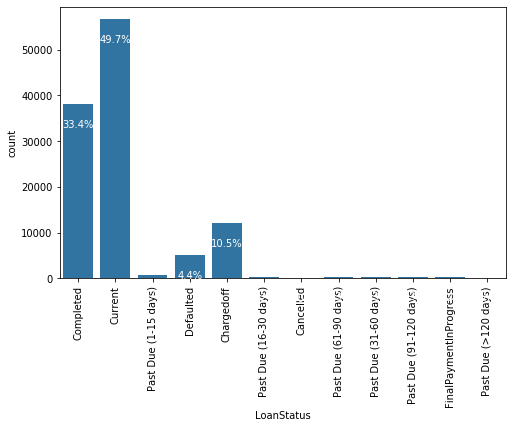

```python
# let's create the plot for LoanStatus which is a nominal categorical variable
base_color=sb.color_palette()[0]
plt.figure(figsize=[8,5])
sb.countplot(data=Prosper_loan, x='LoanStatus',color=base_color)
plt.xticks(rotation=90)
# add annotations
n_points= Prosper_loan.shape[0]
Status_count=Prosper_loan.LoanStatus.value_counts()
locs, labels =plt.xticks() # get the current tick locations and labels

# loop through each pair of locations and labels
for loc, label in zip(locs, labels):

    # get the text property for the label to get the correct count
    count= Status_count[label.get_text()]
    pct_string= '{:0.1f}%'.format(100*count/n_points)

    # print the annotation just below the top of the bar
    plt.text(loc, count-5000, pct_string, ha='center', color='w')
```

## borrower’s APR

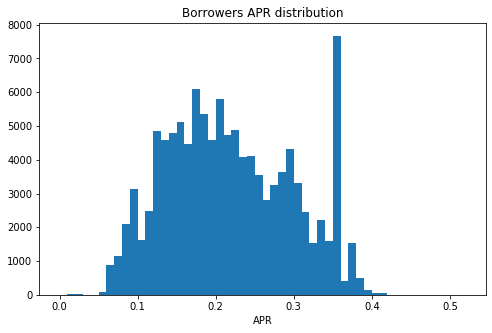

```python
# let's start with a standard scaled-plot (histogram)
bins=np.arange(0,Prosper_loan.BorrowerAPR.max()+0.01,0.01)
plt.figure(figsize=[8,5])
plt.hist(data=Prosper_loan, x='BorrowerAPR', bins=bins)
plt.xlabel('APR')
plt.title('Borrowers APR distribution')
```

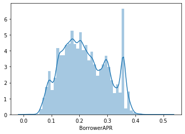

```python
sb.distplot(Prosper_loan['BorrowerAPR'])
```

Borrowers' APR is a plurimodal distribution.

# Loan original amount.

```python
Prosper_loan.LoanOriginalAmount.describe()
```

```
count    113937.00000
mean       8337.01385
std        6245.80058
min        1000.00000
25%        4000.00000
50%        6500.00000
75%       12000.00000
max       35000.00000
Name: LoanOriginalAmount, dtype: float64
```

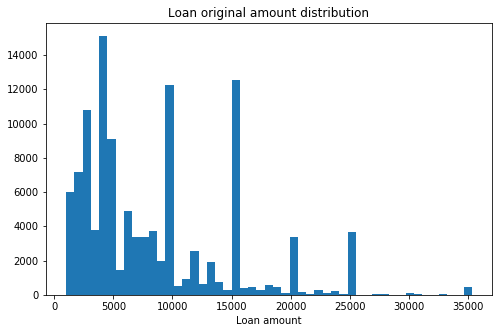

```python
# let's start with a standard scaled-plot (histogram)
bins=np.arange(1000,35000+700,700)
plt.figure(figsize=[8,5])
plt.hist(data=Prosper_loan, x='LoanOriginalAmount', bins=bins)
plt.xlabel('Loan amount')
plt.title('Loan original amount distribution')
```

```python
np.log10(Prosper_loan.LoanOriginalAmount.describe())
```

```
count    5.056665
mean     3.921011
std      3.795588
min      3.000000
25%      3.602060
50%      3.812913
75%      4.079181
max      4.544068
Name: LoanOriginalAmount, dtype: float64
```

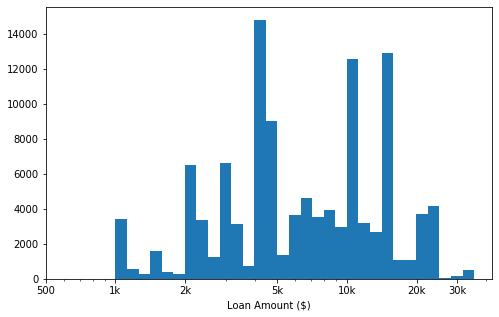

```python
# there's a long tail in the distribution, so let's put it on a log scale instead
log_binsize = 0.05
bins = 10 ** np.arange(3, np.log10(Prosper_loan['LoanOriginalAmount'].max())+log_binsize, log_binsize)

plt.figure(figsize=[8, 5])
plt.hist(data = Prosper_loan, x = 'LoanOriginalAmount', bins = bins)
plt.xscale('log')
plt.xticks([500, 1e3, 2e3, 5e3, 1e4, 2e4,3e4], [500, '1k', '2k', '5k', '10k', '20k','30k'])
plt.xlabel('Loan Amount ($)')
plt.show()
```

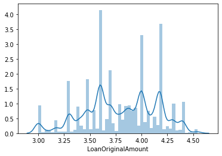

```python
log_data=np.log10(Prosper_loan.LoanOriginalAmount)
sb.distplot(log_data)
```

Plurimodal distribution

# Amount Delinquent

```python
Prosper_loan.AmountDelinquent.describe()
```

```
count    106315.000000
mean        984.507059
std        7158.270157
min           0.000000
25%           0.000000
50%           0.000000
75%           0.000000
max      463881.000000
Name: AmountDelinquent, dtype: float64
```

```python
# let's fill the missing values for AmountDelinquent
mean=Prosper_loan.AmountDelinquent.mean()
Prosper_loan.AmountDelinquent.fillna(mean, inplace=True)
```

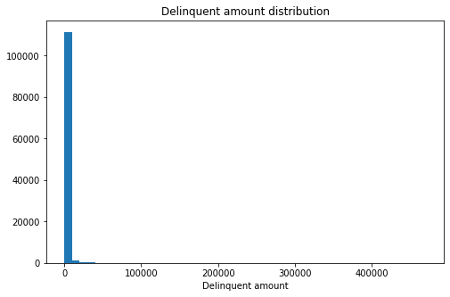

```python
# let's start with a standard scaled-plot (histogram)
bins=np.arange(0,463881+10000,10000)
plt.figure(figsize=[8,5])
plt.hist(data=Prosper_loan, x='AmountDelinquent', bins=bins)
plt.xlabel('Delinquent amount')
plt.title('Delinquent amount distribution')
```

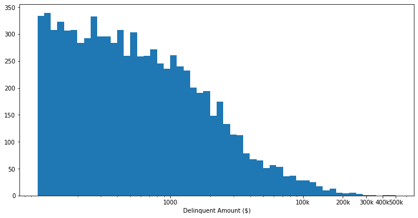

```python
log_binsize = 0.05
bins = 10 ** np.arange(3, np.log10(Prosper_loan.AmountDelinquent.max())+log_binsize, log_binsize)

plt.figure(figsize=[12, 6])
plt.hist(data = Prosper_loan, x = 'AmountDelinquent', bins = bins)
plt.xscale('log')
plt.xticks([10000, 1e5, 2e5, 3e5, 4e5, 5e5], [1000, '100k', '200k', '300k', '400k', '500k'])
plt.xlabel('Delinquent Amount ($)')
plt.show()
```

# Loan Current Days Delinquant

```python
Prosper_loan.LoanCurrentDaysDelinquent.describe()
```

```
count    113937.000000
mean        152.816539
std         466.320254
min           0.000000
25%           0.000000
50%           0.000000
75%           0.000000
max        2704.000000
Name: LoanCurrentDaysDelinquent, dtype: float64
```

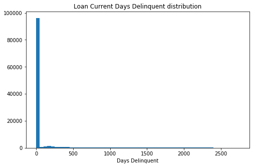

```python
# let's start with a standard scaled-plot (histogram)
bins=np.arange(0,2704+50,50)
plt.figure(figsize=[8,5])
plt.hist(data=Prosper_loan, x='LoanCurrentDaysDelinquent', bins=bins)
plt.xlabel('Days Delinquent')
plt.title('Loan Current Days Delinquent distribution')
```

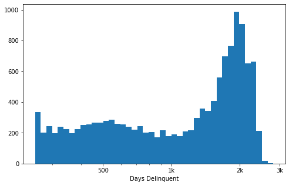

```python
log_binsize = 0.025
bins = 10 ** np.arange(2.4, np.log10(Prosper_loan['LoanCurrentDaysDelinquent'].max())+log_binsize, log_binsize)

plt.figure(figsize=[8, 5])
plt.hist(data = Prosper_loan, x = 'LoanCurrentDaysDelinquent', bins = bins)
plt.xscale('log')
plt.xticks([500, 1e3, 2e3, 3e3], [500, '1k', '2k', '3k'])
plt.xlabel('Days Delinquent')
plt.show()
```

# Distribution of each ordinal variable

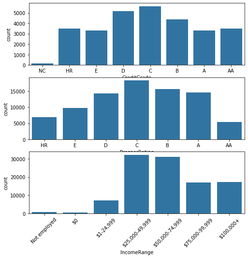

```python
# let's plot all three together to get an idea of each ordinal variable's distribution:CreditGrade, ProsperRating, IncomeRange

fig, ax = plt.subplots(nrows=3, figsize = [8,8])

base_color = sb.color_palette()[0]
sb.countplot(data = Prosper_loan, x = 'CreditGrade', color = base_color, ax = ax[0])
sb.countplot(data = Prosper_loan, x = 'ProsperRating', color = base_color, ax = ax[1])
sb.countplot(data = Prosper_loan, x = 'IncomeRange', color = base_color, ax = ax[2])
plt.xticks(rotation=45)
plt.show()
```

the ProsperRating has almost the same distribution as CreditGrade. The loans go mostly for Income range between 25k to 75k

# Distribution of each nominal variable

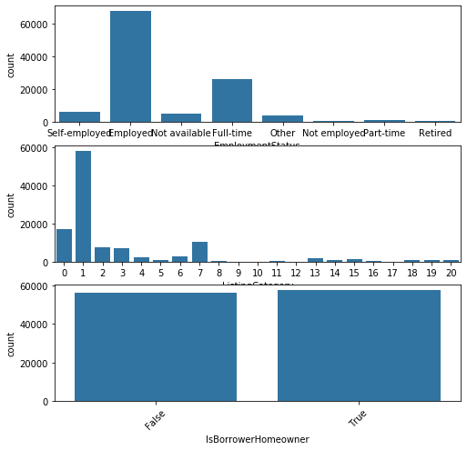

```python
# let's plot all three together to get an idea of each nominal variable's distribution:EmploymentStatus, ListingCategory, IsBorrowerHomeowner

fig, ax = plt.subplots(nrows=3, figsize = [8,8])

base_color = sb.color_palette()[0]
sb.countplot(data = Prosper_loan, x = 'EmploymentStatus', color = base_color, ax = ax[0])
sb.countplot(data = Prosper_loan, x = 'ListingCategory', color = base_color, ax = ax[1])
sb.countplot(data = Prosper_loan, x = 'IsBorrowerHomeowner', color = base_color, ax = ax[2])
plt.xticks(rotation=45)
plt.show()
```

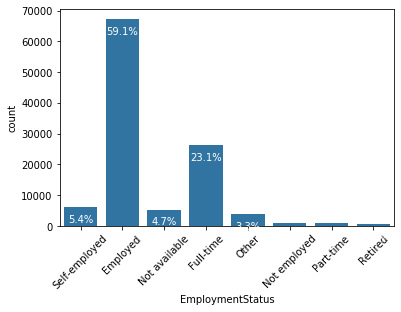

```python
base_color = sb.color_palette()[0]
sb.countplot(data = Prosper_loan, x = 'EmploymentStatus', color = base_color)
plt.xticks(rotation=45)
# add annotations
n_points= Prosper_loan.shape[0]
EmploymentStatus_count=Prosper_loan.EmploymentStatus.value_counts()
locs, labels =plt.xticks() # get the current tick locations and labels

# loop through each pair of locations and labels
for loc, label in zip(locs, labels):

    # get the text property for the label to get the correct count
    count= EmploymentStatus_count[label.get_text()]
    pct_string= '{:0.1f}%'.format(100*count/n_points)

    # print the annotation just below the top of the bar
    plt.text(loc, count-5000, pct_string, ha='center', color='w')
```

let's examine the other variables

# Descriptive Statistics, Outliers, and Axis Limits

```python
Prosper_loan.LenderYield.describe()
```

```
count    113937.000000
mean          0.182701
std           0.074516
min          -0.010000
25%           0.124200
50%           0.173000
75%           0.240000
max           0.492500
Name: LenderYield, dtype: float64
```

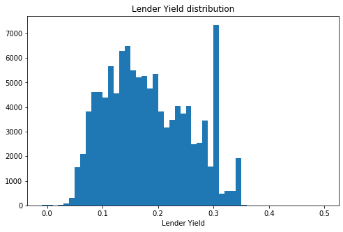

```python
# let's start with a standard scaled-plot (histogram)
bins=np.arange(-0.01,0.5+0.01,0.01)
plt.figure(figsize=[8,5])
plt.hist(data=Prosper_loan, x='LenderYield', bins=bins)
plt.xlabel('Lender Yield')
plt.title('Lender Yield distribution')
```

```python
Prosper_loan.CreditScoreRangeLower.describe()
```

```
count    113346.000000
mean        685.567731
std          66.458275
min           0.000000
25%         660.000000
50%         680.000000
75%         720.000000
max         880.000000
Name: CreditScoreRangeLower, dtype: float64
```

```python
# let's fill the missing values for CreditScoreRangeLower
mean=Prosper_loan.CreditScoreRangeLower.mean()
Prosper_loan.CreditScoreRangeLower.fillna(mean, inplace=True)
```

```python
# let's fill the missing values for CreditScoreRangeLower
mean=Prosper_loan.CreditScoreRangeUpper.mean()
Prosper_loan.CreditScoreRangeUpper.fillna(mean, inplace=True)
```

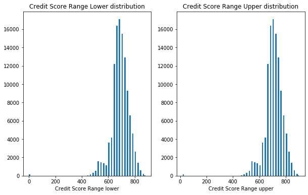

```python
plt.figure(figsize = [10, 6])

# histogram on left: CreditScoreRangeLower
plt.subplot(1, 2, 1)
bins=np.arange(0,880+10,10)
plt.hist(data=Prosper_loan, x='CreditScoreRangeLower', bins=bins)
plt.xlabel('Credit Score Range lower')
plt.title('Credit Score Range Lower distribution')

# histogram on right: CreditScoreRangeUpper
plt.subplot(1, 2, 2)
bins=np.arange(19,899+10,10)
plt.hist(data=Prosper_loan, x='CreditScoreRangeUpper', bins=bins)
plt.xlabel('Credit Score Range upper')
plt.title('Credit Score Range Upper distribution')
```

Apparently there's no difference in the distribution we need to put them on a log scale

```python
Prosper_loan.CreditScoreRangeUpper.describe()
```

```
count    113937.000000
mean        704.567731
std          66.285687
min          19.000000
25%         679.000000
50%         699.000000
75%         739.000000
max         899.000000
Name: CreditScoreRangeUpper, dtype: float64
```

[output not shown]

[figure not shown]

```python
# let's check outlier for CreditScoreRangeLower
plt.figure(figsize = [10, 5])

# histogram on left: full data
plt.subplot(1, 2, 1)
bin_edges = np.arange(0, Prosper_loan['CreditScoreRangeLower'].max()+50, 50)
plt.hist(data = Prosper_loan, x = 'CreditScoreRangerLower', bins = bin_edges)

# histogram on right: focus in on bulk of data < 300
plt.subplot(1, 2, 2)
bin_edges = np.arange(0, 300+50, 50)
plt.hist(data = Prosper_loan, x = 'CreditScoreRangeLower', bins = bin_edges)
plt.xlim(0, 300)
```

As shown above it exists some outliers credit score which are less than 300

[output not shown]

[figure not shown]

```python
# let's check outlier for CreditScoreRangeUpper
plt.figure(figsize = [10, 5])

# histogram on left: full data
plt.subplot(1, 2, 1)
bin_edges = np.arange(19, Prosper_loan['CreditScoreRangeUpper'].max()+1, 1)
plt.hist(data = Prosper_loan, x = 'CreditScoreRangerUpper', bins = bin_edges)

# histogram on right: focus in on bulk of data > 850
plt.subplot(1, 2, 2)
bin_edges = np.arange(850, 850+1, 50)
plt.hist(data = Prosper_loan, x = 'CreditScoreRangeLower', bins = bin_edges)
plt.xlim(851, 1000)
```

# Discuss the distribution(s) of your variable(s) of interest. Were there any unusual points? Did you need to perform any transformations?

I needed to transform Loans Original amount to a log scale, since there was a long tail-distribution, when I transformed it I got a plurimodal distribution.

# Of the features you investigated, were there any unusual distributions? Did you perform any operations on the data to tidy, adjust, or change the form of the data? If so, why did you do this?

# Bivariate analysis

In thebivariate analysis, we are interested in pairwise correlations present between features in the data. Correlations between numeric variables.

```python
list(Prosper_loan)
```

```
['CreditGrade',
 'LoanStatus',
 'BorrowerAPR',
 'BorrowerRate',
 'LenderYield',
 'EstimatedEffectiveYield',
 'ProsperRating',
 'ProsperScore',
 'ListingCategory',
 'EmploymentStatus',
 'EmploymentStatusDuration',
 'IsBorrowerHomeowner',
 'CreditScoreRangeLower',
 'CreditScoreRangeUpper',
 'CurrentCreditLines',
 'AmountDelinquent',
 'AvailableBankcardCredit',
 'DebtToIncomeRatio',
 'IncomeRange',
 'TotalProsperLoans',
 'TotalProsperPaymentsBilled',
 'OnTimeProsperPayments',
 'ProsperPaymentsLessThanOneMonthLate',
 'ProsperPaymentsOneMonthPlusLate',
 'ProsperPrincipalBorrowed',
 'ProsperPrincipalOutstanding',
 'ScorexChangeAtTimeOfListing',
 'LoanCurrentDaysDelinquent',
 'LoanOriginalAmount']
```

```python
numeric_vars = ['BorrowerAPR', 'LenderYield','CreditScoreRangeLower','CreditScoreRangeUpper','AmountDelinquent',
                'LoanOriginalAmount','LoanCurrentDaysDelinquent']
categoric_vars = ['CreditGrade', 'ProsperRating', 'IncomeRange','LoanStatus','EmploymentStatus',
                  'ListingCategory','IsBorrowerHomeowner']
```

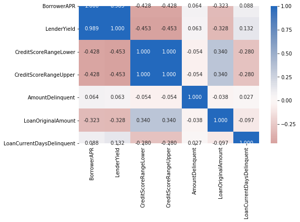

```python
#correlation plot
plt.figure(figsize=[8,5])
sb.heatmap(Prosper_loan[numeric_vars].corr(), annot=True, fmt='.3f', cmap='vlag_r',center=0)
plt.show()
```

As we noticed above, CreditScoreRangeUpper and CreditScoreRangeLower are the same variable.

The original loan is affected by the Credit score range, the APR and the Lender Yield. The better is the Credit score, larger can be the amount of your original loan.

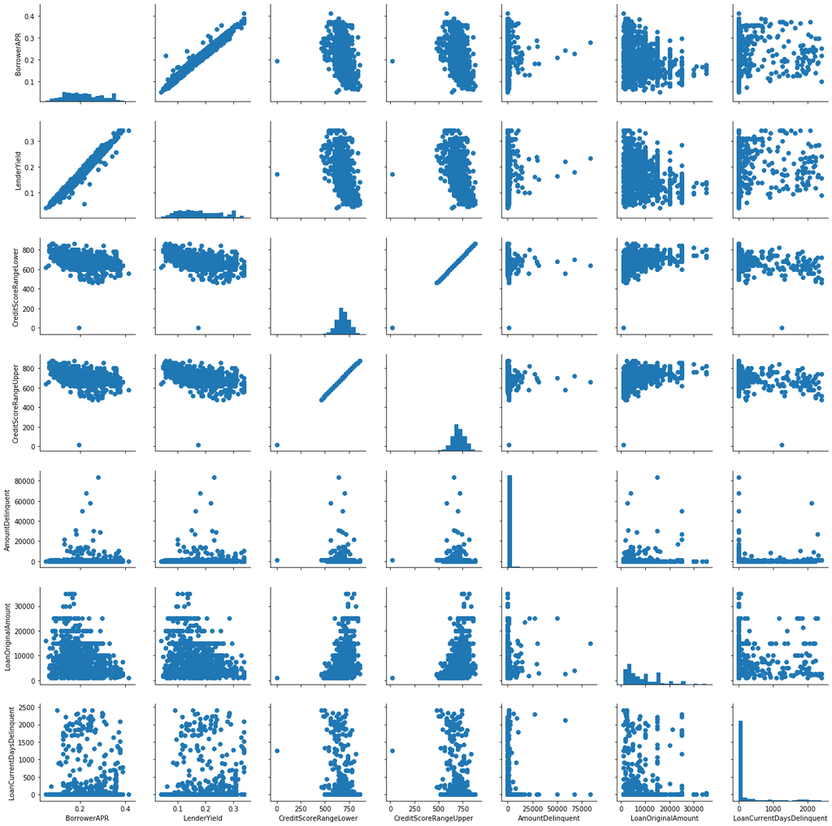

```python
# plot matrix: sample 1000 loans so that plots are clearer and
# they render faster
samples = np.random.choice(Prosper_loan.shape[0], 1000, replace = False)
Prosper_loan_samp = Prosper_loan.loc[samples,:]

g = sb.PairGrid(data = Prosper_loan_samp, vars = numeric_vars)
g = g.map_diag(plt.hist, bins = 20);
g.map_offdiag(plt.scatter)
```

```python
# set bin edges, compute centers
bin_size= 0.25
xbin_edges=np.arange(0.5, Prosper_loan['BorrowerAPR'].max()+bin_size,bin_size)
xbin_center=(xbin_edges+bin_size/2)[:-1]

# compute statistics in each bin
APR_binned=pd.cut(Prosper_loan['BorrowerAPR'], xbin_edges, right=False, include_lowest=True)
LCDD_mean= Prosper_loan['LoanCurrentDaysDelinquent'].groupby(APR_binned).mean()
LCDD_std=Prosper_loan['LoanCurrentDaysDelinquent'].groupby(APR_binned).std()
```

[figure not shown]

```python
plt.errorbar(x=xbin_center, y=LCDD_mean, yerr= LCDD_std);
plt.xlabel('Borrower APR')
plt.ylabel('Loan Current Days Delinquent')
```

### How APR, Loan Orignal amount correlate with the categorical variables.

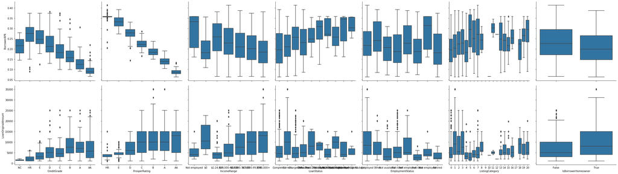

```python
# plot matrix of numeric features against categorical features.

samples = np.random.choice(Prosper_loan.shape[0], 2000, replace = False)
loans_samp = Prosper_loan.loc[samples,:]

def boxgrid(x, y, **kwargs):
    """ Quick hack for creating box plots with seaborn's PairGrid. """
    default_color = sb.color_palette()[0]
    sb.boxplot(x, y, color = default_color)

plt.figure(figsize = [10, 10])
g = sb.PairGrid(data = loans_samp, y_vars = ['BorrowerAPR', 'LoanOriginalAmount'], x_vars = categoric_vars,
                size = 5, aspect = 1)
g.map(boxgrid)
plt.show();
```

let's verify the link between two categorical variables: we will consider our main interest variable, LoanStatus

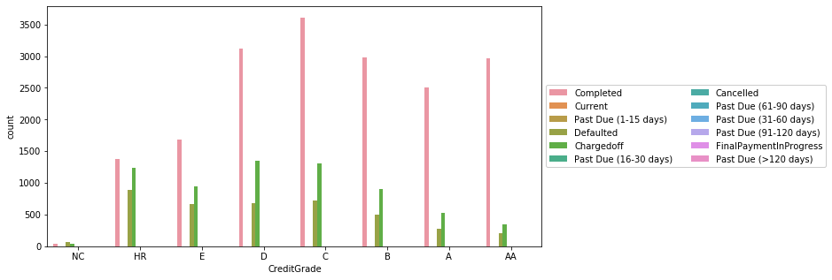

```python
# let's plot y 'LoanStatus' with CreditScore
plt.figure(figsize=[10,5])
sb.countplot(data=Prosper_loan, x='CreditGrade', hue='LoanStatus')
#categoric_vars = ['CreditGrade', 'ProsperRating', 'IncomeRange','LoanStatus','EmploymentStatus',
                 # 'ListingCategory','IsBorrowerHomeowner']
plt.legend(loc=6, ncol=2, bbox_to_anchor=(1.0,0.5),framealpha=1)
```

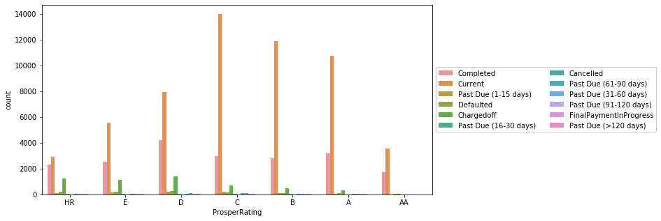

```python
# let's plot y 'LoanStatus' with CreditScore
plt.figure(figsize=[10,5])
sb.countplot(data=Prosper_loan, x='ProsperRating', hue='LoanStatus')
#categoric_vars = ['CreditGrade', 'ProsperRating', 'IncomeRange','LoanStatus','EmploymentStatus',
                 # 'ListingCategory','IsBorrowerHomeowner']
plt.legend(loc=6, ncol=2, bbox_to_anchor=(1.0,0.5),framealpha=1)
```

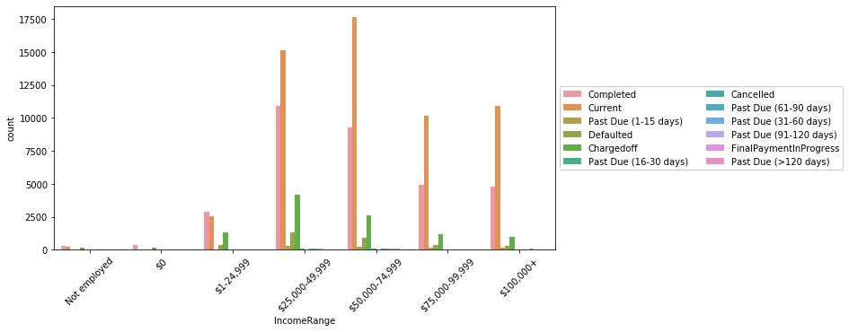

```python
# let's plot y 'LoanStatus' with IncomeRange
plt.figure(figsize=[10,5])
sb.countplot(data=Prosper_loan, x='IncomeRange', hue='LoanStatus')

plt.legend(loc=6, ncol=2, bbox_to_anchor=(1.0,0.5),framealpha=1)
plt.xticks(rotation=45)
```

### What factors affect a loan’s outcome status?

I am looking for which features better explain loan's outcome status. In this extent, some key statistics like correlation will be useful.

LoanStatus will be the dependant variable or y; such variables : CreditScoreRangeUpper,AmountDelinquent, LoanCurrentDaysDelinquant

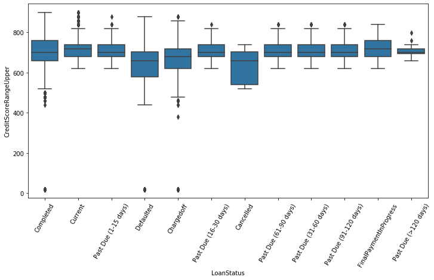

```python
# Relationship between LoanStatus and CreditScoreRangeUpper
# this relationship is between a categorical and a numeric variables
base_color=sb.color_palette()[0]
plt.figure(figsize=[12,6])
sb.boxplot(data=Prosper_loan, x='LoanStatus', y='CreditScoreRangeUpper', color=base_color);
plt.xticks(rotation=60)
```

We noted some outliers for Completed, Defaulted and Chargedoff Loan status, while there are no outliers for cancelled Loan; We noted as well that the IQ range is larger for cancelled loans.

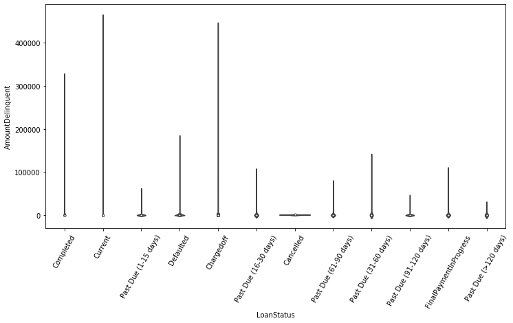

```python
# Relationship between LoanStatus and AmountDelinquent
# this relationship is between a categorical and a numeric variables
base_color=sb.color_palette()[0]
plt.figure(figsize=[12,6])
sb.violinplot(data=Prosper_loan, x='LoanStatus', y='AmountDelinquent', color=base_color);
plt.xticks(rotation=60)
```

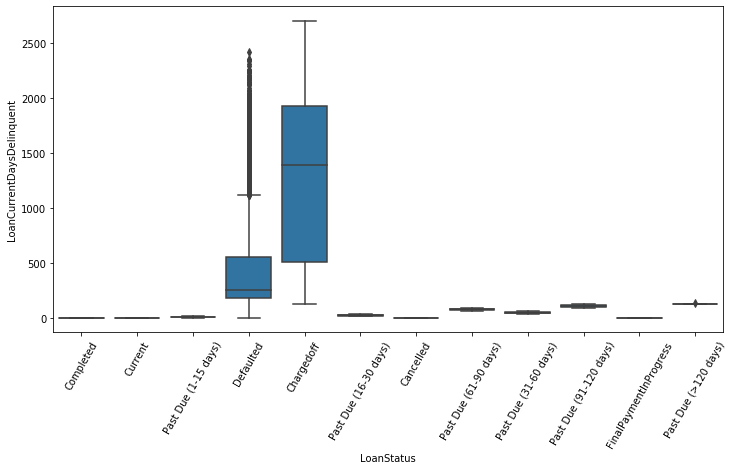

```python
# Relationship between LoanStatus and LoanCurrentDaysDelinquent
# this relationship is between a categorical and a numeric variables
base_color=sb.color_palette()[0]
plt.figure(figsize=[12,6])
sb.boxplot(data=Prosper_loan, x='LoanStatus', y='LoanCurrentDaysDelinquent', color=base_color);
plt.xticks(rotation=60)
```

There are some outliers in defaulted Loan status, the IQ is larger for chargedoff loan.

# What affects the borrower’s APR or interest rate?

Borrower APR will be the dependant variable (y); x(CreditScorRangeLower,CreditScoreRangeUpper,CreditGrade As we already noted, there's any difference between CreditScoreRangeLower and CreditScoreRangeUpper, we will then use one of them.

Like other types of debt, the interest rates for personal loans depend on the lender, your credit scores and your credit history. An estimated range of interest rates on personal loans for consumers with fair to good credit is currently between 6% and 36%. APR, or annual percentage rate, is your interest rate stated as a yearly rate. An APR for a loan can include fees you may be charged, like origination fees. APR is important because it can give you a good idea of how much you'll pay to take out a loan

This rate describes how much in interest charges you will pay on the balance of your loan over a year period. The higher rate will be your APR. An annual percentage rate (APR) is a broader measure of the cost of borrowing money than the interest rate. The APR reflects the interest rate, any points, mortgage broker fees, and other charges that you pay to get the loan. For that reason, your APR is usually higher than your interest rate.

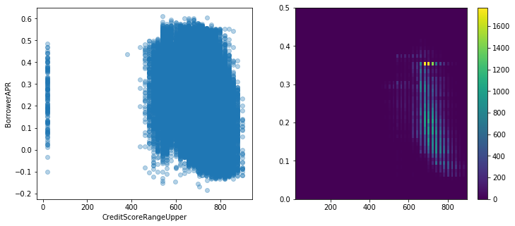

```python
# let's use a scatterplot : Borrower APR vs Credit Score Range

plt.figure(figsize=[12,5])

#left plot: scatterplot of discrete data with jitter and transparency
plt.subplot(1,2,1)
sb.regplot(data=Prosper_loan, x='CreditScoreRangeUpper', y='BorrowerAPR', fit_reg=False, x_jitter=0.2, y_jitter=0.2, scatter_kws={'alpha': 1/3})

# right plot : heat map with bin edges between values
plt.subplot(1,2,2)
bins_x=np.arange(19, 899+10, 10)
bins_y=np.arange(0, 0.5+0.01,0.01)
plt.hist2d(data=Prosper_loan, x='CreditScoreRangeUpper', y='BorrowerAPR', bins=[bins_x, bins_y])
plt.colorbar();
```

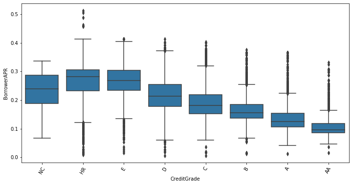

```python
#relationship between APR and CreditGrade
base_color=sb.color_palette()[0]
plt.figure(figsize=[12,6])
sb.boxplot(data=Prosper_loan, x='CreditGrade', y='BorrowerAPR', color=base_color);
plt.xticks(rotation=60)
```

Credit grade can really impact the borrower rate.

Are there differences between loans depending on how large the original loan amount was? We will consider fondamental keys, to see how the original loan amount can affect APR for instance.

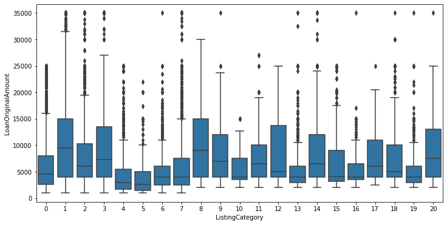

```python
#relationship between Loan amount and Income Range, Listing Category and employment status
base_color=sb.color_palette()[0]
plt.figure(figsize=[12,6])
sb.boxplot(data=Prosper_loan, x='ListingCategory', y='LoanOriginalAmount', color=base_color);
#plt.xticks(rotation=60)
```

Listing Category 1, 3,8,9,12,14,17,18,20 1-Debt Consolidation, 3-Business, 8-Baby&Adoption, 9 - Boat, 12 - Green Loans, 14 - Large Purchases, 17 - RV, 18 - Taxes, 20 - Wedding Loans. There are differences between loans depending on the category for the loan.

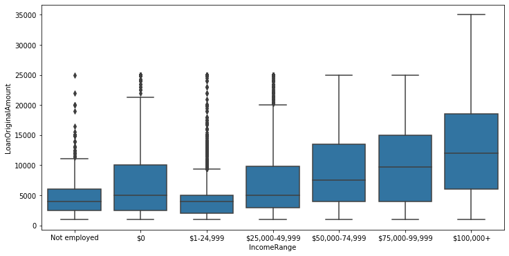

```python
base_color=sb.color_palette()[0]
plt.figure(figsize=[12,6])
sb.boxplot(data=Prosper_loan, x='IncomeRange', y='LoanOriginalAmount', color=base_color);
```

The original loan amount is affected by the income range.

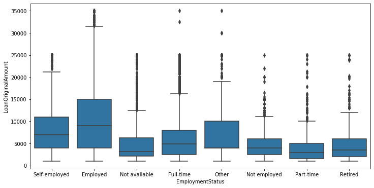

```python
base_color=sb.color_palette()[0]
plt.figure(figsize=[12,6])
sb.boxplot(data=Prosper_loan, x='EmploymentStatus', y='LoanOriginalAmount', color=base_color);
```

Original loan amount is impacted by the employment status.

## Talk about some of the relationships you observed in this part of the investigation. How did the feature(s) of interest vary with other features in the dataset?

The APR is affected by the Credit score range, the lower your Credit score is the higher is your APR. The original loan is affected by the Credit score range, the APR and the Lender Yield. The better is the Credit score, larger can be the amount of your original loan.

Relationship between LoanStatus and CreditScoreRangeUpper:

- We noted some outliers for Completed, Defaulted and Chargedoff Loan status, while there are no outliers for cancelled Loan;
- We noted as well that the IQ range is larger for cancelled loans. Relationship between LoanStatus and LoanCurrentDaysDelinquent
- There are some outliers in defaulted Loan status, the IQ is larger for chargedoff loan.

Borrower APR vs Credit Score Range

Relationship between Loan amount and Income Range, Listing Category and employment status

- There are differences between loans depending on the category for the loan.
- The original loan amount is affected by the income range. The higher is your income range the higher can be the original loan amount.
- Original loan amount is impacted by the employment status.

## Did you observe any interesting relationships between the other features (not the main feature(s) of interest)?

There is a strong relationship between Borrower APR and Lender Yield. More the annual percentage rate is high more will be the earnings of the lender.

# Multivariate exploration

### Loan Status

1. I am interested in knowing how Credit Score Range and IncomeRange combined affect the LoanStatus
2. I am interested in knowing how Amount delinquent and current days delinquent affect LoanStatus

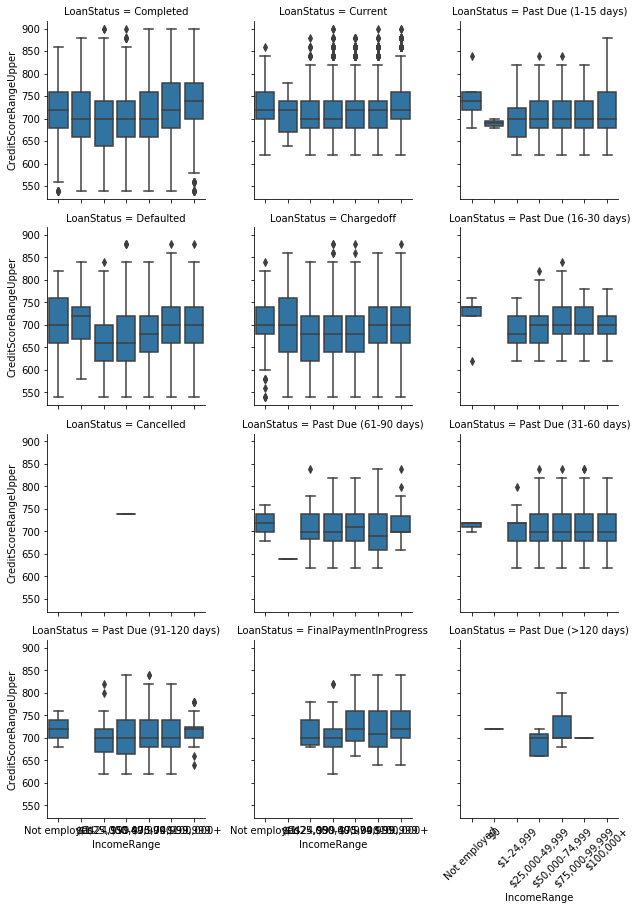

```python
g=sb.FacetGrid(data=Prosper_loan, col='LoanStatus',margin_titles=True, size=3,col_wrap=3)
g.map(sb.boxplot, 'IncomeRange', 'CreditScoreRangeUpper');
plt.xticks(rotation=45)
```

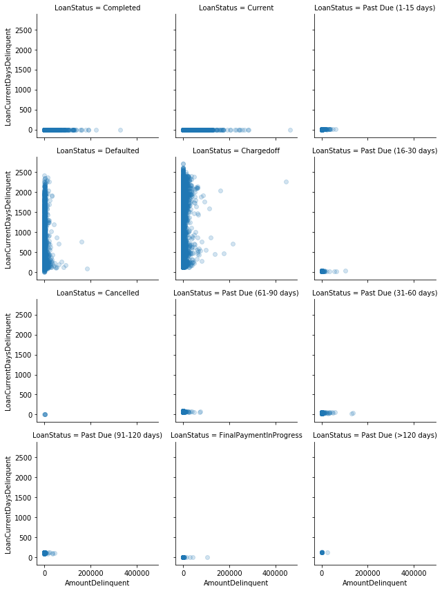

```python
# relationship between LoanStatus, CurrentDaysDelinquent and Amount Delinquent
g=sb.FacetGrid(data=Prosper_loan, col='LoanStatus', size=3, col_wrap=3)
g.map(plt.scatter, 'AmountDelinquent', 'LoanCurrentDaysDelinquent',alpha=1/5);
```

Borrower APR vs Credit Score Range

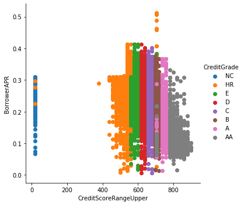

```python
g=sb.FacetGrid(data=Prosper_loan, hue='CreditGrade', size=5)
g.map(plt.scatter, 'CreditScoreRangeUpper', 'BorrowerAPR')
#need to set scale
#g.set(xscale='log')
#x_ticks=[0.1,0.3,1,3,10,30,100,300]
#g.set(xticks=x_ticks, xticklabels=x_ticks)
g.add_legend()
```

Relationship between Loan amount and Income Range, Listing Category and employment status

- There are differences between loans depending on the category for the loan.
- The original loan amount is affected by the income range. The higher is your income range the higher can be the original loan amount.
- Original loan amount is impacted by the employment status.

[figure not shown]

```python
g=sb.FacetGrid(data=Prosper_loan, col='EmploymentStatus', row='IncomeRange', margin_titles=True)
g.map(plt.hist, 'LoanOriginalAmount');
#need to set scale
g.set(xscale='log')
x_ticks=[0.1,0.3,1,3,10,30,100,300]
g.set(xticks=x_ticks, xticklabels=x_ticks)
g.add_legend()
```

## Talk about some of the relationships you observed in this part of the investigation. Were there features that strengthened each other in terms of looking at your feature(s) of interest?

Credit score are linked to credit score range, which combined together have a strong impact on APR

Income Range is linked to Employment Status which combined togethermake a difference on the original loan amount.